# NYPD Shooting Report

### I have included all my commands that lead to everything as code blocks. I showed only the output of the most integral ones. I hope you enjoy :D

## Beginnings

```r
library(tidyverse)
library(RcppRoll)
library(lubridate)
```

The URL our data is located in

```r
url_in <- "https://data.cityofnewyork.us/api/views/833y-fsy8/rows.csv?accessType=DOWNLOAD"
```

Loading our data into R

```r
nyc_data <- read_csv(url_in)
```

Changing the date column to be an actual datetime object

```r
nyc_data <- nyc_data %>% mutate(OCCUR_DATE = mdy(OCCUR_DATE))
```

Remove unnecessary columns that don’t help our analysis

```r
nyc_data <- nyc_data %>% select(-c(X_COORD_CD,Y_COORD_CD,Latitude, Longitude,Lon_Lat))

nyc_data
```

| INCIDENT_KEY | OCCUR_DATE | OCCUR_TIME | BORO | PRECINCT | JURISDICTION_CODE | LOCATION_DESC | STATISTICAL_MURDER_FLAG | PERP_AGE_GROUP | PERP_SEX | PERP_RACE | VIC_AGE_GROUP | VIC_SEX | VIC_RACE |
| --- | --- | --- | --- | --- | --- | --- | --- | --- | --- | --- | --- | --- | --- |
| 236168668 | 2021-11-11 | 15:04:00 | BROOKLYN | 79 | 0 | NA | FALSE | NA | NA | NA | 18-24 | M | BLACK |
| 231008085 | 2021-07-16 | 22:05:00 | BROOKLYN | 72 | 0 | NA | FALSE | 45-64 | M | ASIAN / PACIFIC ISLANDER | 25-44 | M | ASIAN / PACIFIC ISLANDER |
| 230717903 | 2021-07-11 | 01:09:00 | BROOKLYN | 79 | 0 | NA | FALSE | <18 | M | BLACK | 25-44 | M | BLACK |
| 237712309 | 2021-12-11 | 13:42:00 | BROOKLYN | 81 | 0 | NA | FALSE | NA | NA | NA | 25-44 | M | BLACK |
| 224465521 | 2021-02-16 | 20:00:00 | QUEENS | 113 | 0 | NA | FALSE | NA | NA | NA | 25-44 | M | BLACK |
| 228252164 | 2021-05-15 | 04:13:00 | QUEENS | 113 | 0 | NA | TRUE | NA | NA | NA | 25-44 | M | BLACK |
| 226950018 | 2021-04-14 | 21:08:00 | BRONX | 42 | 0 | COMMERCIAL BLDG | TRUE | NA | NA | NA | 18-24 | M | BLACK |
| 237710987 | 2021-12-10 | 19:30:00 | BRONX | 52 | 0 | NA | FALSE | NA | NA | NA | 25-44 | M | BLACK |
| 224701998 | 2021-02-22 | 00:18:00 | MANHATTAN | 34 | 0 | NA | FALSE | NA | NA | NA | 25-44 | M | BLACK HISPANIC |
| 225295736 | 2021-03-07 | 06:15:00 | BROOKLYN | 75 | 0 | NA | TRUE | 25-44 | M | BLACK HISPANIC | 25-44 | M | WHITE HISPANIC |

[output cut: 9990 more lines]

Quick Summary of the data

```r
summary(nyc_data)
```

```
##   INCIDENT_KEY         OCCUR_DATE          OCCUR_TIME           BORO
##  Min.   :  9953245   Min.   :2006-01-01   Length:25596      Length:25596
##  1st Qu.: 61593633   1st Qu.:2009-05-10   Class1:hms        Class :character
##  Median : 86437258   Median :2012-08-26   Class2:difftime   Mode  :character
##  Mean   :112382648   Mean   :2013-06-13   Mode  :numeric
##  3rd Qu.:166660833   3rd Qu.:2017-07-01
##  Max.   :238490103   Max.   :2021-12-31
##
##     PRECINCT      JURISDICTION_CODE LOCATION_DESC      STATISTICAL_MURDER_FLAG
##  Min.   :  1.00   Min.   :0.0000    Length:25596       Mode :logical
##  1st Qu.: 44.00   1st Qu.:0.0000    Class :character   FALSE:20668
##  Median : 69.00   Median :0.0000    Mode  :character   TRUE :4928
##  Mean   : 65.87   Mean   :0.3316
##  3rd Qu.: 81.00   3rd Qu.:0.0000
##  Max.   :123.00   Max.   :2.0000
##                   NA's   :2
##  PERP_AGE_GROUP       PERP_SEX          PERP_RACE         VIC_AGE_GROUP
##  Length:25596       Length:25596       Length:25596       Length:25596
##  Class :character   Class :character   Class :character   Class :character
##  Mode  :character   Mode  :character   Mode  :character   Mode  :character
##
##
##
##
##    VIC_SEX            VIC_RACE
##  Length:25596       Length:25596
##  Class :character   Class :character
##  Mode  :character   Mode  :character
##
##
##
##
```

## Visualisation

Let’s do some visualisation, for that we will first create a couple of interesting tables

- The number of records by Boro->Precint
- The total victim race
- The total perpetrator race

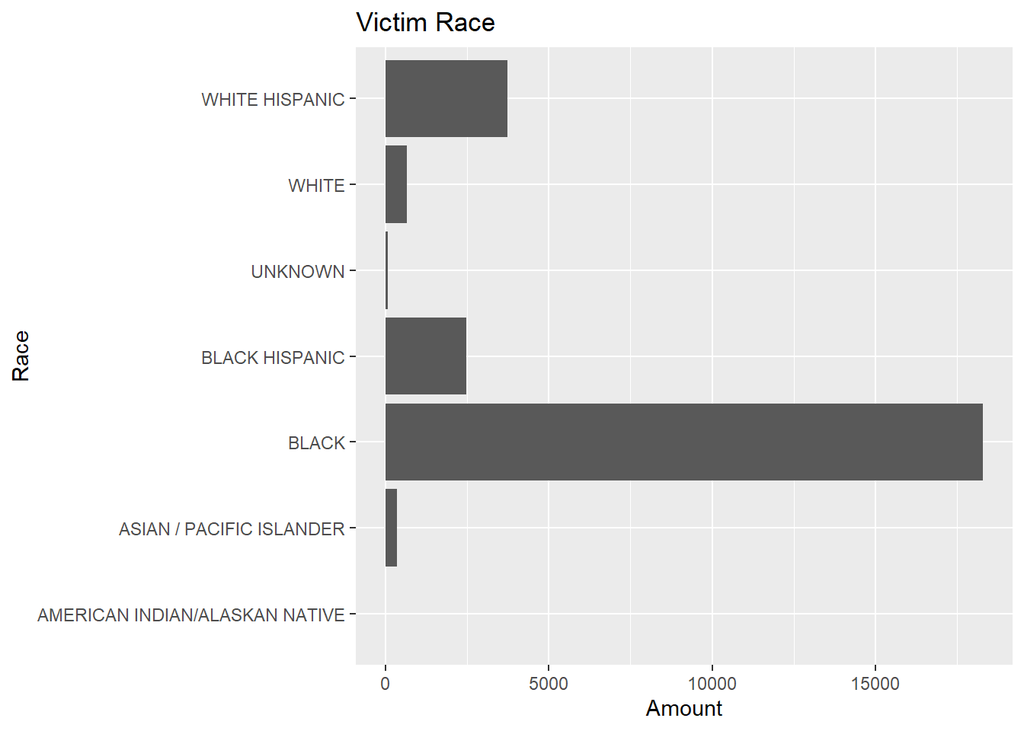

```r
nyc_boro <- nyc_data %>% group_by(BORO,PRECINCT) %>% count()


nyc_vic_total <- nyc_data %>% group_by(VIC_RACE) %>% count()

nyc_vic_total %>% ggplot(aes(y=VIC_RACE,x=n)) + geom_bar(stat="identity") + labs(title = "Victim Race",x="Amount", y="Race")
```

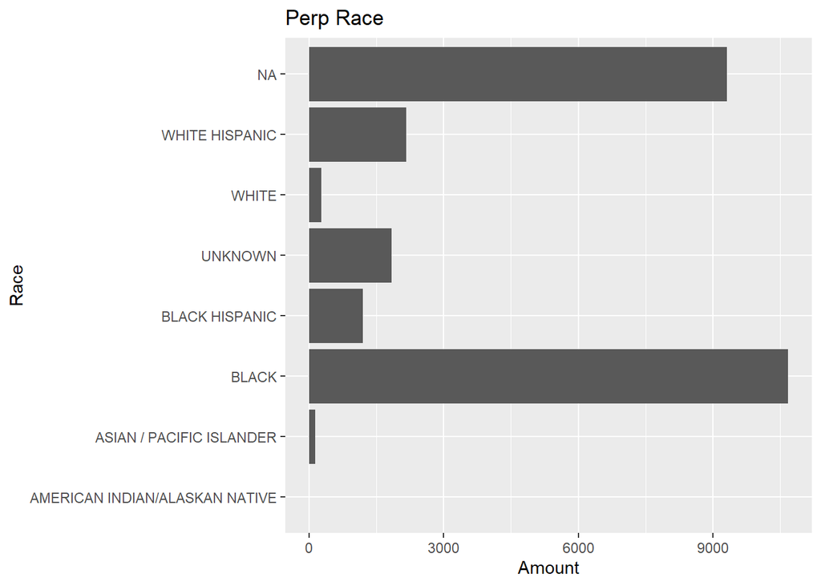

```r
nyc_perp_total <- nyc_data %>% group_by(PERP_RACE) %>% count()

nyc_perp_total %>% ggplot(aes(y=PERP_RACE,x=n)) + geom_bar(stat="identity") + labs(title = "Perp Race",x="Amount", y="Race")
```

How many incidents per Date? Lets also plot this

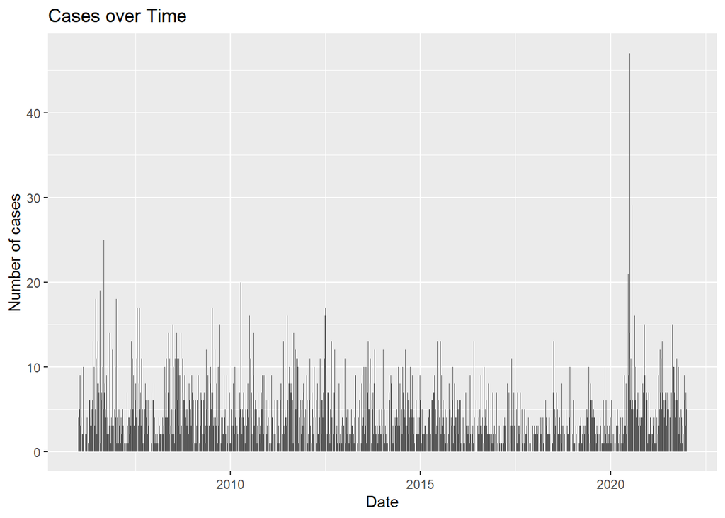

```r
nyc_date_total <- nyc_data %>% group_by(OCCUR_DATE) %>% count()


nyc_date_total %>% ggplot(aes(x=OCCUR_DATE,y=n)) + geom_bar(stat="identity") + labs(title = "Cases over Time",x="Date", y="Number of cases")
```

Preparing for Analysis of total cases over time and plotting for total cases over time

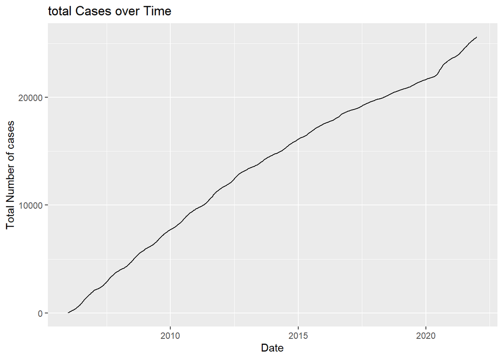

```r
nyc_date_total$total <- cumsum(nyc_date_total$n)
nyc_date_total %>% ggplot(aes(x=OCCUR_DATE,y=total)) + geom_line(stat="identity") + labs(title = "total Cases over Time",x="Date", y="Total Number of cases")
```

## Modeling

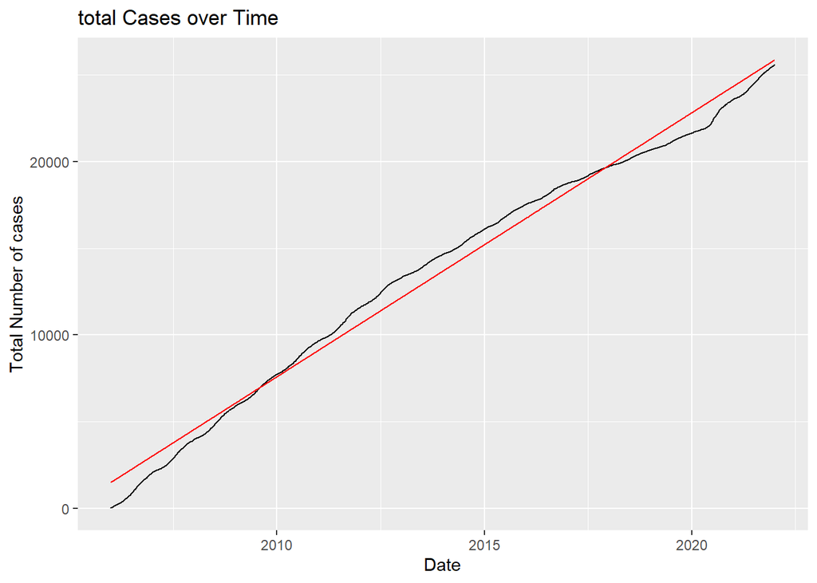

```r
mod <- lm( total ~ OCCUR_DATE , data=nyc_date_total)

mod2 <- lm( n ~ OCCUR_DATE, data=nyc_date_total)

nyc_date_total$pred1 <- predict(mod)

nyc_date_total$pred2 <- predict(mod2)

ggplot(nyc_date_total, aes(x=OCCUR_DATE)) +  geom_line(aes(y=total), color="black") + geom_line(aes(y=pred1), color="red") + labs(title = "total Cases over Time",x="Date", y="Total Number of cases")
```

### About Bias

This Data could have some certain racial bias. Not every crime gets reported. Some neighbourhoods with racial bias might be profiled more. Or in general, the people might be misidentified.